# Sobrevivientes del Titanic parte I

Los aspirantes a científicos de datos generalmente somos personas curiosas a las que les gusta navegar por internet buscando recursos que apoyen y consoliden nuestros conocimientos.

Un sitio muy popular donde se pueden encontrar mucha información sobre este tema es el sitio web **kaggle.com** en el que se desarrollan competencias entre personas apasionadas por los datos con el objetivo de generar los mejores modelos en función de las características particulares de cada conjunto de datos.

La base de datos del Titanic es uno de los primeros pasos para adentrarse en el mundo de la ciencia de datos desde el aprendizaje en ésta página **Kaggle** con muchos recursos a la mano. El objetivo de la base de datos y, la competencia es tratar de predecir si un pasajero sobrevive o no.

Como en todos los ejercicios primero vamos a cargar los paquetes de funciones que se utilizarán en el ejercicio de estimación.

```r
library("easypackages")
my_packages <- c("tidyverse", "knitr")
libraries(my_packages)
```

Posteriormente vamos a subir la tabla de datos con la que trabajaremos

```r
train <- read_csv("train.csv")
test <- read_csv("test.csv")
```

Vamos a echar una ojeada a la tabla de datos para saber como están compuestas las variables.

```r
glimpse(train)
```

```
## Observations: 891
## Variables: 12
## $ PassengerId <int> 1, 2, 3, 4, 5, 6, 7, 8, 9, 10, 11, 12, 13, 14, 15,...
## $ Survived    <int> 0, 1, 1, 1, 0, 0, 0, 0, 1, 1, 1, 1, 0, 0, 0, 1, 0,...
## $ Pclass      <int> 3, 1, 3, 1, 3, 3, 1, 3, 3, 2, 3, 1, 3, 3, 3, 2, 3,...
## $ Name        <chr> "Braund, Mr. Owen Harris", "Cumings, Mrs. John Bra...
## $ Sex         <chr> "male", "female", "female", "female", "male", "mal...
## $ Age         <dbl> 22, 38, 26, 35, 35, NA, 54, 2, 27, 14, 4, 58, 20, ...
## $ SibSp       <int> 1, 1, 0, 1, 0, 0, 0, 3, 0, 1, 1, 0, 0, 1, 0, 0, 4,...
## $ Parch       <int> 0, 0, 0, 0, 0, 0, 0, 1, 2, 0, 1, 0, 0, 5, 0, 0, 1,...
## $ Ticket      <chr> "A/5 21171", "PC 17599", "STON/O2. 3101282", "1138...
## $ Fare        <dbl> 7.2500, 71.2833, 7.9250, 53.1000, 8.0500, 8.4583, ...
## $ Cabin       <chr> NA, "C85", NA, "C123", NA, NA, "E46", NA, NA, NA, ...
## $ Embarked    <chr> "S", "C", "S", "S", "S", "Q", "S", "S", "S", "C", ...
```

Como podemos ver arriba, en nuestra tabla de datos hay doce variables de las cuales **Fare**, **Age** y **PassengerId**, las 9 variables más con de tipo categoricas sin embargo la variable **Pclass** está como un entero o variable numérica por lo que debemos recodificarla para obtener resultados satisfactorios.

Una de las tareas principales al realizar análisis estadístico es conocer la base de datos y las relaciones entre las variables y también los valores perdidos. Para esto aplicaremos una función que nos ayudará a contar los valores perdidos en cada una de las columnas en nuestra tabla de datos.

```r
sapply(train, function(x){sum(is.na(x))})
```

```
## PassengerId    Survived      Pclass        Name         Sex         Age
##           0           0           0           0           0         177
##       SibSp       Parch      Ticket        Fare       Cabin    Embarked
##           0           0           0           0         687           2
```

Según el conteo, las variables que tienen más valores perdidos son *Age*, *Cabin* y *Embarked*. Confirmamos esto de manera gráfica con una función que nos ayuda a visualizar los valores perdidos de mejor manera.

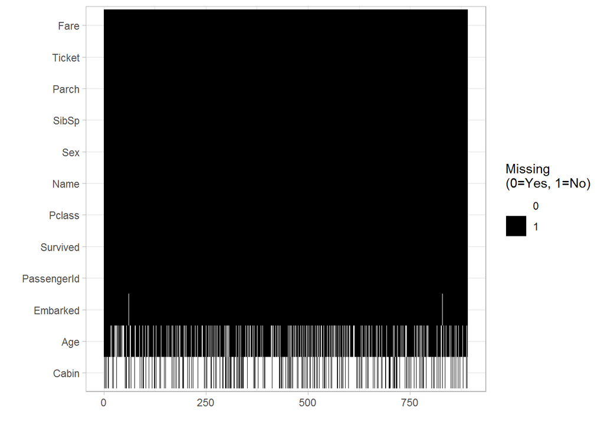

```r
plot_Missing <- function(data_in, title = NULL){
  temp_df <- as.data.frame(ifelse(is.na(data_in), 0, 1))
  temp_df <- temp_df[,order(colSums(temp_df))]
  data_temp <- expand.grid(list(x = 1:nrow(temp_df), y = colnames(temp_df)))
  data_temp$m <- as.vector(as.matrix(temp_df))
  data_temp <- data.frame(x = unlist(data_temp$x), y = unlist(data_temp$y), m = unlist(data_temp$m))
  ggplot(data_temp) + geom_tile(aes(x=x, y=y, fill=factor(m))) +
    scale_fill_manual(values=c("white", "black"), name="Missing\n(0=Yes, 1=No)") +
    theme_light() + ylab("") + xlab("") + ggtitle(title)
}


plot_Missing(train)
```

Confirmamos por lo tanto que las variables con mayor número de valores perdidos son la edad, la cabina y el lugar en el que se embarcaron.

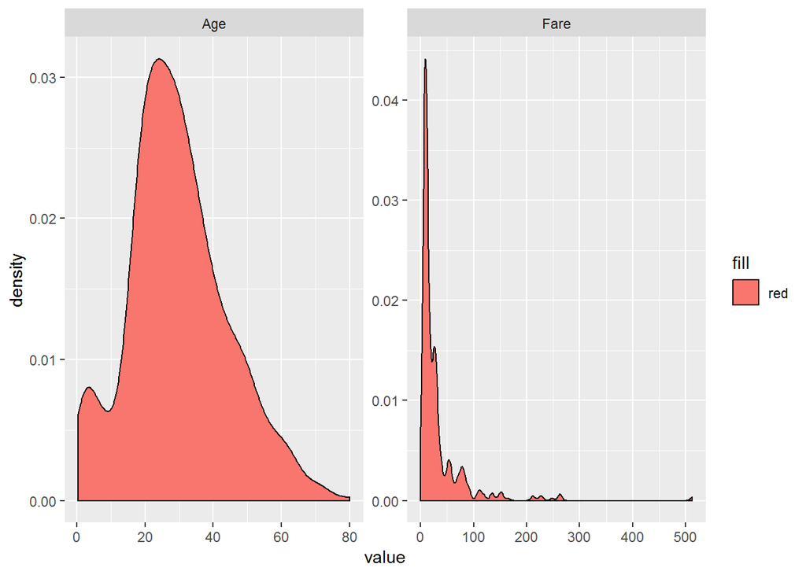

```r
train %>%
  keep(is.numeric) %>%
  select(Age, Fare) %>%
  gather() %>%
  ggplot(aes(x = value, fill = "red")) +
  facet_wrap(~key, scales = "free") +
  geom_density()
```

Podemos ver por ejemplo que la edad tiene una distribución casi normal con un sezgo positivo, adicionalmente observamos que la tarifa está sezgada hacia la derecha. Observamos también que las variables tienen algunos datos atípicos principalmente la variable *fare*. También podemos observar que las variables están en diferentes escalas por lo que les aplicaremos una técnica de normalización llamada *Z score normalization* con la función scale

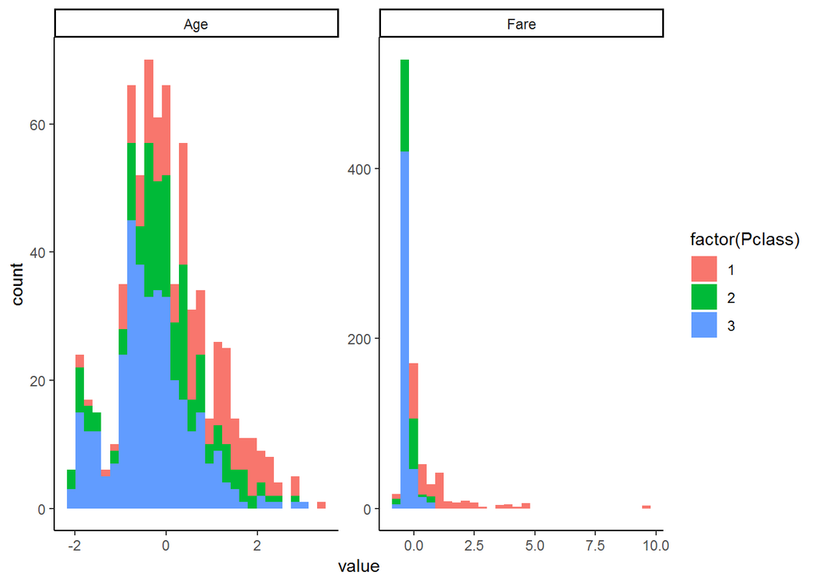

```r
train %>%
  keep(is.numeric) %>%
  select(Age, Fare, Pclass) %>%
  mutate(Age = scale(Age),
         Fare = scale(Fare)) %>%
  gather(key = "key", value = "value", -Pclass) %>%
  ggplot(aes(x= value, fill = factor(Pclass))) +
  geom_histogram() +
  facet_wrap(~key, scales = "free")  +
  theme_classic()
```

Podemos observar que la variable edad tiene un comportamiento casi normal con algunas exepciones o casos atípicos de personas de avanzada edad. La variable que tiene mayores problemas es Fare. Se observa en el histograma que no tiene un comportamiento normal debido a ciertas variables atípicas. Vamos a confirmar esto con un diagrama de hoja y bigotes que nos permite visualizar de mejor manera las observaciones atípicas.

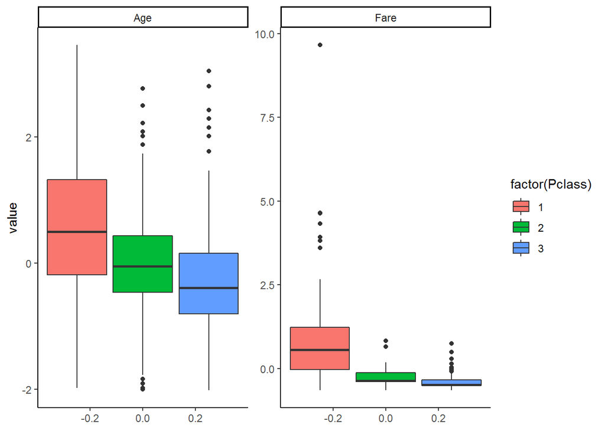

```r
train %>%
  keep(is.numeric) %>%
  select(Age, Fare, Pclass) %>%
  mutate(Age = scale(Age),
         Fare = scale(Fare)) %>%
  gather(key = "key", value = "value", -Pclass) %>%
  ggplot(aes(y=value, fill = factor(Pclass))) +
  facet_wrap(~key, scales = "free") +
  geom_boxplot()+
  theme_classic()
```

Suponemos que la variable Fare está relacionada con la clase donde viajan los pasajeros, por lo que vamos a observar los valores mínimos, máximos y desviación estándar de las variables.

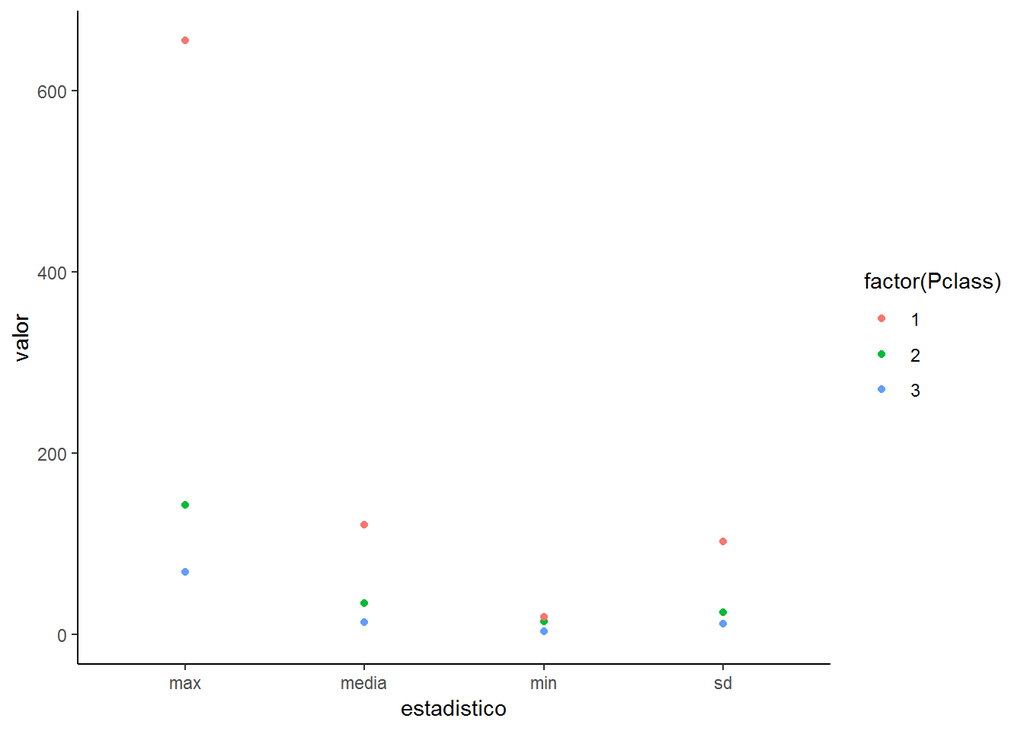

```r
train %>%
  filter(Fare != 0) %>%
  group_by(Pclass) %>%
  summarise(max = max(Fare, na.rm = TRUE), media = mean(Fare, na.rm = TRUE), min = min(Fare, na.rm = TRUE), sd = sd(Fare, na.rm = TRUE)) %>%
  gather(estadistico, valor, -Pclass) %>%
  ggplot(aes(x = estadistico, y = valor, colour = factor(Pclass))) +
  geom_point(stat = "identity", position = "stack") +
  theme_classic()
```

Observamos en la grafica de arriba que:

- El valor máximo pagado por los boletos es sustancialmente diferente cuando comparamos por clase.
- La diferencia del precio promedio de los boletos es mayor entre primera clase. Segunda y tercera clase la diferencia no es tan grande.

Hasta ahora hemos observado varias características significativas en las variables que hemos analizado

1. La distribución de la edad entre los pasajeros tiene una distribución casi normal sin embargo hay un pequeño salto en la cantidad de menores que viajan
2. Las personas que viajan en tercera clase son las que tienen una distribución mas normal, las personas viajando en primera clase son en promedio de mayor edad
3. En promedio la tarifa pagada por las personas viajando en primera clase es mayor. Sin embargo tienen una distribución más sezgada y con valores atípicos.

Vamos a ver ahora en qué clase viajaban una mayor cantidad de personas.

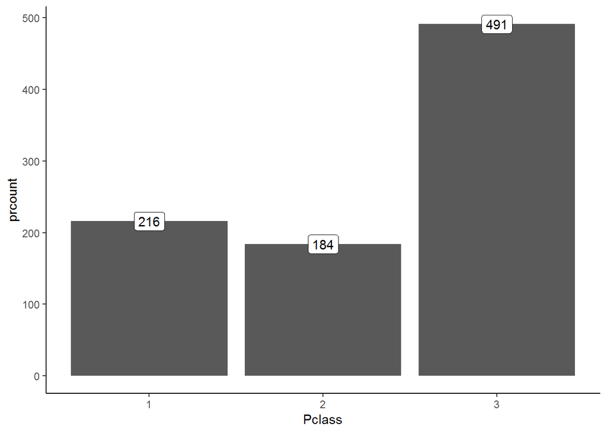

```r
train %>%
  group_by(Pclass) %>%
  summarise(prcount = n()) %>%
  ggplot(aes(Pclass, prcount)) +
  geom_bar(stat = "identity") +
  geom_label(aes(label = prcount)) +
  theme_classic()
```

Observamos que la mayor cantidad de personas viajan en tercera clase. Superando sustancialmente a segunda y primera clase.

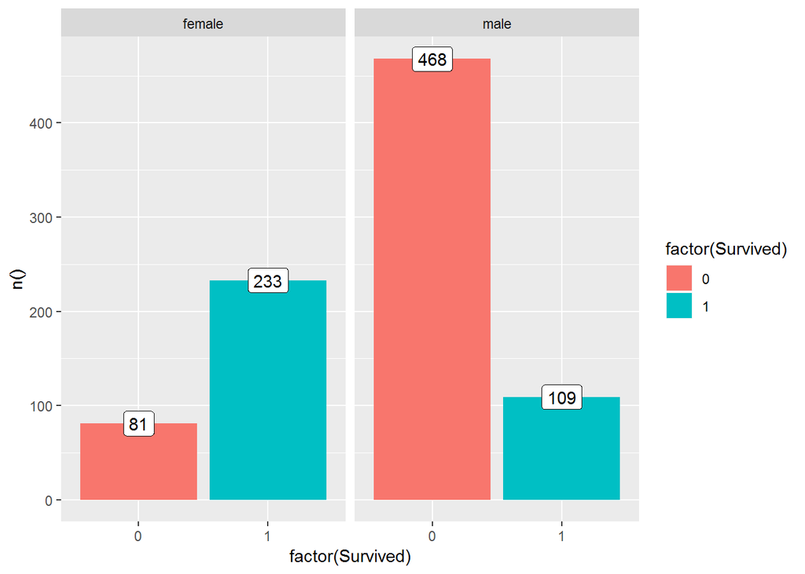

```r
train %>%
  select(Sex, Survived, Pclass) %>%
  group_by(Survived, Sex) %>%
  summarise(n()) %>%
  ggplot(aes(x = factor(Survived) , y = `n()`)) +
  geom_bar(stat = "identity", aes(fill = factor(Survived))) +
  geom_label(aes(label = `n()`)) +
  facet_wrap(~Sex)
```

En la gráfica anterior observamos diferentes cosas pero primero tenemos que explicar cómo se lee.

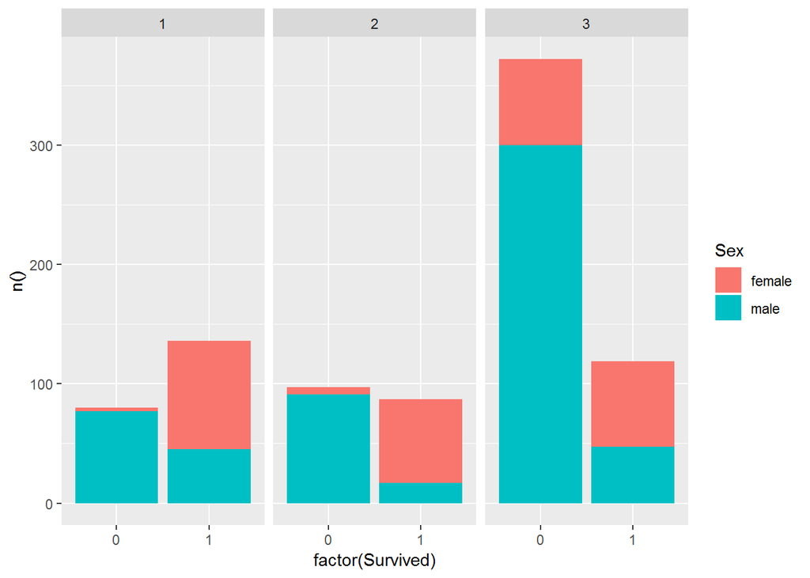

```r
train %>%
  select(Sex, Survived, Pclass) %>%
  group_by(Sex, Survived, Pclass) %>%
  summarise(n()) %>%
  ggplot(aes(x = factor(Survived), y = `n()`)) +
  geom_bar(stat = "identity", aes(fill = Sex)) +
  facet_wrap(~Pclass)
```

Por ejemplo vamos a comparar las barras que se encuentran encima del número cero de color azúl, o sea hombres que no sobrevivieron.

Vemos que la mayor cantidad de hombres que no sobrevivieron se encuentran en tercera clase luego segunda clase y al final primera clase. Los datos los observamos en la tabla de abajo.

Del total de hombres que no sobrevivieron 300 viajaban en tercera clase, 91 en segunda clase y 77 en primera clase. Por lo que podemos inferir que debido a la gran diferencia entre las varaibles éste puede ser un predictor importante

```r
train %>%
  select(Sex, Survived, Pclass) %>%
  group_by(Sex, Survived, Pclass) %>%
  summarise(n()) %>%
  arrange(desc(`n()`)) %>%
  filter(Survived == 0 & Sex %in% "male") %>%
  kable()
```

| Sex | Survived | Pclass | n() |
| --- | --- | --- | --- |
| male | 0 | 3 | 300 |
| male | 0 | 2 | 91 |
| male | 0 | 1 | 77 |

Ahora que sucedió con las mujeres que no sobrevivieron de acuerdo a la clase en la que viajaban.

```r
train %>%
  select(Sex, Survived, Pclass) %>%
  group_by(Sex, Survived, Pclass) %>%
  summarise(n()) %>%
  arrange(desc(`n()`)) %>%
  filter(Survived == 0 & Sex %in% "female") %>%
  kable()
```

| Sex | Survived | Pclass | n() |
| --- | --- | --- | --- |
| female | 0 | 3 | 72 |
| female | 0 | 2 | 6 |
| female | 0 | 1 | 3 |

Se observa que la mayor cantidad de mujeres que no sobrevivieron al accidente se encontraban en tercera clase, luego las que viajan en segunda y al final primera clase. Recordemos que una de las causas de la tragedia y a que las personas que sobrevivieron fueron tan pocas es por que no había suficientes barcos salvavidas. Lo que nos hace suponer que se les daba preferencia a las mujeres y, particularmente a las que viajaban en primera clase.

```r
train %>%
  select(Sex, Survived, Pclass) %>%
  group_by(Sex, Survived, Pclass) %>%
  summarise(n()) %>%
  filter(Survived == 1) %>%
  arrange(desc(`n()`)) %>%
  kable()
```

| Sex | Survived | Pclass | n() |
| --- | --- | --- | --- |
| female | 1 | 1 | 91 |
| female | 1 | 3 | 72 |
| female | 1 | 2 | 70 |
| male | 1 | 3 | 47 |
| male | 1 | 1 | 45 |
| male | 1 | 2 | 17 |

De los sobrevivientes podemos observar que la mayor proporción es para mujeres en primera clase, posteriormente mujeres en tercera y al final mujeres en segunda clase.

Los hombres la mayor cantidad de sobrevivientes son 47 que viajaban en tercera clase, 45 en primera y 17 en segunda.

Hasta ahora sólo hemos explorado las variables **Pclass**, **Survived** y **Sex** nos falta **Age**, **Fare**, **Cabin**